# 07 – Why do our results differ from the authors’? (case study 2)

Testing the possible causes, one at a time

Author

Minh Le, Jeanne Leclerc

Published

October 13, 2026

## Goal

Notebooks 05 and 06 left two differences with the authors:

1. **gene selection**: our best protocol (B+, the wrapper’s defaults) recovered 160 of the authors’ 174 selected genes, missed 14 and added 7;
2. **orientations**: on the rebuilt input, the links of the network were mostly recovered, but many orientations and genuine causations were not.

Here we test the possible causes one at a time, each with a small experiment.

**Inputs:** the MI tables and recovered counts of notebook 05 (`results/case2/05_rebuild_input/`), the network of notebook 06, the authors’ files, and one extra MIIC run on the authors’ input without its duplicated columns (`results/case2/07_differences/authors_dedup/`, made with `scripts/run_miic.R`, see section 5).

## Setup

```r
library(tidyverse)
library(Seurat)
library(miic)
root <- getwd()
while (!file.exists(file.path(root, "scripts", "helpers.R"))) {
  if (dirname(root) == root) stop("Repository root not found. Open the repository folder in Positron.")
  root <- dirname(root)
}
source(file.path(root, "scripts", "helpers.R"))

job_dir     <- file.path(root, "data", "case2", "causalccc_server_w0788tM1wzXGHLzNaKKa")
nb05_dir    <- file.path(root, "results", "case2", "05_rebuild_input")
nb06_dir    <- file.path(root, "results", "case2", "06_rebuilt_network")
results_dir <- file.path(root, "results", "case2", "07_differences")
dir.create(results_dir, recursive = TRUE, showWarnings = FALSE)

cell_types <- c("Fibroblasts", "T_cell", "DCs")
strip      <- function(v) str_remove_all(v, "_(Fibroblasts|T_cell|DCs)")

mi_tables <- readRDS(file.path(nb05_dir, "mi_tables.rds"))
rebuilt   <- readRDS(file.path(nb05_dir, "rebuild_inputs.rds"))
lr_roles  <- rebuilt$lr_roles

mosaic   <- read_tsv(file.path(job_dir, "input.tsv"), guess_max = Inf, show_col_types = FALSE)
lr_pairs <- read_tsv(file.path(job_dir, "clean_interact_edges.tsv"),
                     col_names = c("ligand", "receptor"), show_col_types = FALSE)
row_type <- case_when(!is.na(mosaic$labels_Fibroblasts) ~ "Fibroblasts",
                      !is.na(mosaic$labels_T_cell)      ~ "T_cell",
                      !is.na(mosaic$labels_DCs)         ~ "DCs")
col_type <- column_cell_type(mosaic, row_type)

# The authors' selected genes per cell type (without L-R genes, metadata and suffixes), as in notebook 05
authors_selected <- map(set_names(cell_types), \(t) {
  genes <- unique(strip(names(mosaic)[col_type == t & !str_detect(names(mosaic), "^(labels|condition)_")]))
  setdiff(genes, lr_roles$gene[lr_roles$cell_type == t])
})
```

# Part 1 – Gene selection

## 1. A different version of the code?

The authors’ server job ran on 21 January 2025. The CausalCCC functions (`causalCCC.utils.R`, `causalCCC.wrapper.R`) were added to the public repository `miicTeam/CausalCCC` on 6 December 2024, and the md5 checksums of both files are identical in all five later commits, up to `0aa8586` (23 January 2025), which only changes the README (checked with the GitHub API on 7 October 2026). And notebook 04 showed that `miic` itself gives exactly the authors’ network.

**Unless the authors used unpublished code, the code version is not the cause.**

## 2. A different gene order?

`causalCCC.MIselection()` computes MI in blocks of 100 genes, each block in one call to `miic`. If the result for a gene depended on the other genes of its block, a different gene order in the authors’ Seurat object would change the MI values. We recompute the MI of two features of interest in dendritic cells after shuffling the gene order, and compare with notebook 05.

```r
order_file <- file.path(results_dir, "mi_shuffled_order.rds")

if (file.exists(order_file)) {
  mi_shuffled <- readRDS(order_file)
} else {
  MIselection <- causalCCC.MIselection   # with the Seurat 5 fix of notebook 05
  body(MIselection) <- parse(text = gsub('slot = "counts"', 'layer = "counts"',
                                         deparse(body(MIselection)), fixed = TRUE))[[1]]
  set.seed(1)
  shuffled <- sample(nrow(rebuilt$counts))
  so <- CreateSeuratObject(counts = rebuilt$counts[shuffled, ], meta.data = rebuilt$meta)
  invisible(capture.output(suppressMessages(
    mi_shuffled <- MIselection(so, interact_ident = "cell_type", oneinteract = "DCs", goi = c("CD74", "CXCR4"),
                               metadata_list = c("labels", "condition"), return_full = TRUE))))
  mi_shuffled <- as_tibble(mi_shuffled) |> mutate(foi = as.character(foi))
  saveRDS(mi_shuffled, order_file)
}

mi_shuffled |>
  filter(foi %in% c("CD74", "CXCR4")) |>
  inner_join(filter(mi_tables, cell_type == "DCs"), by = c("variables", "foi"), suffix = c("_shuffled", "_original")) |>
  summarise(pairs = n(), largest_difference = max(abs(value_shuffled - value_original)))
```

```
# A tibble: 1 × 2
  pairs largest_difference
  <int>              <dbl>
1 34660                  0
```

The values are exactly the same: each MI value depends only on the two variables. Since our counts are the authors’ counts (notebook 05, section 2), **our MI values are the authors’**. The differences can only come from the choices made when selecting genes from these values.

## 3. Different selection settings?

Three settings of the wrapper could have been changed:

- the **number of genes** `n_genes` kept by `causalCCC.MIselection()` (default `max(15, min(4 × genes of interest, 100))`);
- the **cap of 8** ligands or receptors used as features of interest in each run (in the wrapper, `ligands[1:min(length(ligands), 8)]`);
- the **metadata** used as features of interest, on the sender and receiver sides.

`run_protocol()` generalises protocol B of notebook 05 (one run per sender → receiver direction) to these settings, and `score()` counts the authors’ selected genes we miss and the genes we add.

```r
directions <- lr_pairs |>
  transmute(sender = col_type[ligand], receiver = col_type[receptor],
            ligand = strip(ligand), receptor = strip(receptor))

mi_by_type <- split(mi_tables, mi_tables$cell_type)

run_protocol <- function(meta_sender, meta_receiver, cap = 8, n_genes = default_n_genes) {
  one_side <- function(t, goi, meta) {
    goi <- head(unique(goi), cap)
    select_genes(mi_by_type[[t]], foi = c(goi, meta), n_genes = n_genes(goi))
  }
  runs <- directions |>
    group_by(sender, receiver) |>
    summarise(sender_genes   = list(one_side(first(sender), ligand, meta_sender)),
              receiver_genes = list(one_side(first(receiver), receptor, meta_receiver)),
              .groups = "drop")
  map(set_names(cell_types), \(t) {
    unique(c(unlist(runs$sender_genes[runs$sender == t]), unlist(runs$receiver_genes[runs$receiver == t])))
  })
}

score <- function(selected, protocol) {
  map(cell_types, \(t) {
    ours <- setdiff(selected[[t]], c(lr_roles$gene[lr_roles$cell_type == t], "labels", "condition"))
    tibble(protocol, cell_type = t,
           missing = length(setdiff(authors_selected[[t]], ours)),
           extra   = length(setdiff(ours, authors_selected[[t]])))
  }) |> list_rbind()
}

both_metadata <- c("labels", "condition")
```

**The number of genes.** With both metadata on both sides and the cap of 8, we vary `n_genes`, either as the default formula or as a fixed number:

```r
n_genes_tests <- c(list("default" = default_n_genes),
                   map(set_names(paste("fixed", c(20, 24, 25, 26, 30))),
                       \(name) { n <- as.integer(str_extract(name, "[0-9]+")); \(goi) n }))

imap(n_genes_tests, \(f, name) score(run_protocol(both_metadata, both_metadata, cap = 8, n_genes = f), name)) |>
  list_rbind() |>
  group_by(protocol) |>
  # detail first: inside summarise(), a new column hides the column of the same name for the next ones
  summarise(detail = paste(cell_type, missing, extra, sep = ":", collapse = "  "),
            missing = sum(missing), extra = sum(extra))
```

```
# A tibble: 6 × 4
  protocol detail                                missing extra
  <chr>    <chr>                                   <int> <int>
1 default  Fibroblasts:4:3  T_cell:2:0  DCs:8:4       14     7
2 fixed 20 Fibroblasts:8:0  T_cell:9:0  DCs:10:0      27     0
3 fixed 24 Fibroblasts:1:0  T_cell:1:0  DCs:5:0        7     0
4 fixed 25 Fibroblasts:0:0  T_cell:0:0  DCs:5:0        5     0
5 fixed 26 Fibroblasts:0:1  T_cell:0:1  DCs:5:1        5     3
6 fixed 30 Fibroblasts:0:7  T_cell:0:6  DCs:5:5        5    18
```

With **25 genes per run**, fibroblasts and T cells are reproduced exactly (0 missing, 0 extra). Below 25, genes are missing; above, genes are added. Only 5 dendritic cell genes are still missing.

**The 5 missing dendritic cell genes.** For each, its rank among all genes by MI with each feature of interest of dendritic cells (rank 1 = highest MI):

```r
still_missing <- setdiff(authors_selected$DCs,
                         run_protocol(both_metadata, both_metadata, cap = 8, n_genes = \(goi) 25)$DCs)

mi_by_type$DCs |>
  group_by(foi) |>
  mutate(rank = rank(-value, ties.method = "first")) |>
  ungroup() |>
  filter(variables %in% still_missing) |>
  select(gene = variables, foi, rank) |>
  pivot_wider(names_from = foi, values_from = rank) |>
  select(gene, TMEM219, TNFRSF14, everything())
```

```
# A tibble: 5 × 20
  gene   TMEM219 TNFRSF14   MIF  PPIA LGALS9   TNF  GAS6  CD74  CD44 CXCR4  FPR3
  <chr>    <int>    <int> <int> <int>  <int> <int> <int> <int> <int> <int> <int>
1 ARL6I…    1265        1   568   157   2359   581   279   160   100  2944   884
2 GRN          3     6055   463   496    283  6046  6636   107   459  6994   190
3 NDUFS5      93        2   189   134    282  9587   705   269   348   740   338
4 PFDN5        1      176    82    45    671 10503   293    35    68   335   433
5 VAMP8        2    15079   553   242    159 15086  1165   208  1392 15156   189
# ℹ 8 more variables: ITGAX <int>, ITGB2 <int>, CCR7 <int>, ITGAM <int>,
#   BSG <int>, IL13RA1 <int>, labels <int>, condition <int>
```

They are the top 3 genes of **TMEM219** (PFDN5, VAMP8, GRN) and the top 2 of **TNFRSF14** (ARL6IP5, NDUFS5), so the top-3 rule of `causalCCC.MIselection()` selects them as soon as these two receptors are features of interest. But the cap of 8 removes them: TMEM219 is the 10th receptor of the fibroblasts → dendritic cells direction and TNFRSF14 the 9th of the T cells → dendritic cells direction.

```r
directions |>
  filter(receiver == "DCs") |>
  group_by(sender) |>
  summarise(receptors = paste(seq_along(unique(receptor)), unique(receptor), sep = ".", collapse = " "))
```

```
# A tibble: 2 × 2
  sender      receptors
  <chr>       <chr>
1 Fibroblasts 1.CD74 2.CD44 3.CXCR4 4.FPR3 5.ITGAX 6.ITGB2 7.CCR7 8.ITGAM 9.BSG…
2 T_cell      1.CD74 2.CD44 3.CXCR4 4.FPR3 5.BSG 6.IL13RA1 7.ITGAM 8.ITGB2 9.TN…
```

**Without the cap**, with 25 genes per run, for all combinations of metadata:

```r
metadata_options <- list(none = NULL, labels = "labels", condition = "condition", both = both_metadata)

expand_grid(sender = names(metadata_options), receiver = names(metadata_options), cap = c(8, Inf)) |>
  pmap(\(sender, receiver, cap) {
    score(run_protocol(metadata_options[[sender]], metadata_options[[receiver]], cap = cap, n_genes = \(goi) 25),
          paste(sender, receiver, cap)) |>
      summarise(sender_metadata = sender, receiver_metadata = receiver, cap = cap,
                missing = sum(missing), extra = sum(extra))
  }) |>
  list_rbind() |>
  arrange(missing + extra) |>
  print(n = 12)
```

```
# A tibble: 32 × 5
   sender_metadata receiver_metadata   cap missing extra
   <chr>           <chr>             <dbl>   <int> <int>
 1 labels          both                Inf       0     0
 2 both            labels              Inf       0     0
 3 both            both                Inf       0     0
 4 labels          labels              Inf       4     0
 5 labels          both                  8       5     0
 6 both            labels                8       5     0
 7 both            both                  8       5     0
 8 none            both                Inf       1     6
 9 condition       labels              Inf       1     6
10 condition       both                Inf       1     6
11 labels          labels                8       9     0
12 none            labels              Inf       5     6
# ℹ 20 more rows
```

**The authors’ selection is reproduced exactly** (0 missing, 0 extra in all three cell types) by: one wrapper run per sender → receiver direction, all the ligands or receptors of the direction as features of interest (no cap of 8), the two metadata (`labels` and `condition`) as features of interest, and **25 genes** per run. The metadata matter: `labels` alone on both sides is not enough (4 genes missing), but the selection is exact as soon as `condition` is added on one side (`labels` on the sender side and both on the receiver side, or the reverse) or on both sides. The simplest combination, used below, is both metadata on both sides.

# Part 2 – Orientations

## 4. Same input, same network

Notebook 04 already ruled out the MIIC step itself: on the authors’ input, our run gives exactly their links, orientations and genuine causations. So differences in orientations can only come from the input.

## 5. The duplicated columns?

Part 1 shows that our rebuilt input would contain exactly the authors’ genes with the right settings. The authors’ input **without its 14 duplicated columns** is therefore the input we would build ourselves. We ran MIIC on it with the server’s settings (one thread, same seed), with `scripts/run_miic.R`:

```r
dedup_dir <- file.path(results_dir, "authors_dedup")

# How the input was made: the authors' files minus every column identical to an earlier column of the same cell type
dropped <- unlist(map(cell_types, \(t) {
  block <- mosaic[row_type == t, col_type == t]
  names(block)[duplicated(as.list(block))]
}))
dropped
```

```
 [1] "S100A6_Fibroblasts"  "B2M_Fibroblasts"     "S100A10_Fibroblasts"
 [4] "FTH1_Fibroblasts"    "ACTB_T_cell"         "B2M_T_cell"
 [7] "S100A6_T_cell"       "SH3BGRL3_T_cell"     "H3F3B"
[10] "ANXA2"               "S100A10_DCs"         "TMSB10_DCs"
[13] "LGALS1_DCs"          "S100A4_DCs"
```

```r
dedup_result <- readRDS(file.path(dedup_dir, "miic_result.rds"))
```

```r
lr_links_authors <- link_name(lr_pairs$ligand, lr_pairs$receptor)

edges_authors <- read_tsv(file.path(job_dir, "edgesList.miic.summary.txt"), show_col_types = FALSE)
edges_dedup   <- as_tibble(dedup_result$all.edges.summary) |>
  filter(!(link_name(x, y) %in% lr_links_authors & Nxy_ai %in% 0))   # placeholder rows (notebook 02)
edges_ours    <- read_tsv(file.path(nb06_dir, "edges.tsv"), show_col_types = FALSE)

# Every variable identified as "<gene>_<cell type>", so that the three networks can be compared;
# the two copies of a duplicated gene become one node
key_of <- tibble(variable = names(mosaic), cell_type = col_type) |>
  mutate(key = if_else(str_detect(variable, "^(labels|condition)_"), variable,
                       paste0(strip(variable), "_", cell_type))) |>
  pull(key, name = variable)
key_of_ours <- set_names(unique(c(edges_ours$x, edges_ours$y)))

gene_links <- function(edge_list, keys) {
  edge_list |>
    filter(type == "P") |>
    mutate(a = keys[x], b = keys[y]) |>
    filter(a != b, !link_name(x, y) %in% c(lr_links_authors, link_name(keys[lr_pairs$ligand], keys[lr_pairs$receptor]))) |>
    transmute(link = link_name(a, b),
              orientation = if_else(a == pmin(a, b) | infOrt %in% c(1, 6), infOrt, -infOrt),
              is_causal) |>
    distinct(link, .keep_all = TRUE)
}

networks <- list(authors = gene_links(edges_authors, key_of),
                 authors_without_duplicates = gene_links(edges_dedup, key_of),
                 ours_notebook_06 = gene_links(edges_ours, key_of_ours))

map(networks, \(n) tibble(links = nrow(n), oriented = sum(abs(n$orientation) == 2),
                          bidirected = sum(n$orientation == 6), genuine_causation = sum(n$is_causal == "Y"))) |>
  list_rbind(names_to = "network")
```

```
# A tibble: 3 × 5
  network                    links oriented bidirected genuine_causation
  <chr>                      <int>    <int>      <int>             <int>
1 authors                      525      149         39                30
2 authors_without_duplicates   525       97         18                30
3 ours_notebook_06             498       86         15                19
```

**Pairwise comparison.** For two networks: the Jaccard index of their gene–gene links, and, on the shared links, the fraction with the same orientation and the number of genuine causations found in both.

```r
compare_networks <- function(a, b) {
  shared <- inner_join(networks[[a]], networks[[b]], by = "link", suffix = c("_a", "_b"))
  tibble(comparison = paste(a, "vs", b),
         jaccard = nrow(shared) / n_distinct(c(networks[[a]]$link, networks[[b]]$link)),
         shared_links = nrow(shared),
         same_orientation = mean(shared$orientation_a == shared$orientation_b),
         opposite_orientation = sum(abs(shared$orientation_a) == 2 & shared$orientation_a == -shared$orientation_b),
         causal_a = sum(shared$is_causal_a == "Y"), causal_b = sum(shared$is_causal_b == "Y"),
         causal_both = sum(shared$is_causal_a == "Y" & shared$is_causal_b == "Y"))
}

bind_rows(compare_networks("authors", "authors_without_duplicates"),
          compare_networks("authors_without_duplicates", "ours_notebook_06"),
          compare_networks("authors", "ours_notebook_06")) |>
  print(width = Inf)
```

```
# A tibble: 3 × 8
  comparison                                     jaccard shared_links
  <chr>                                            <dbl>        <int>
1 authors vs authors_without_duplicates            1              525
2 authors_without_duplicates vs ours_notebook_06   0.820          461
3 authors vs ours_notebook_06                      0.820          461
  same_orientation opposite_orientation causal_a causal_b causal_both
             <dbl>                <int>    <int>    <int>       <int>
1            0.834                    0       30       30          23
2            0.941                    1       24       17          12
3            0.787                    2       25       17           9
```

**A caveat on this table.** In the authors’ network, a link of a duplicated gene appears once per copy (two rows, or four when both genes are duplicated), and `gene_links()` keeps only the first row of each link. If the two copies do not get the same orientation, the orientation kept for that link depends on which copy comes first, so the comparisons involving the authors’ network are not reliable for these links. We therefore look separately at the links that involve a duplicated gene, keeping every row:

```r
dup_keys <- unique(unname(key_of[dropped]))   # "<gene>_<cell type>" of the 14 duplicated genes

all_rows <- function(edge_list, keys) {
  edge_list |>
    filter(type == "P") |>
    mutate(a = keys[x], b = keys[y]) |>
    filter(a != b, !link_name(x, y) %in% c(lr_links_authors, link_name(keys[lr_pairs$ligand], keys[lr_pairs$receptor]))) |>
    transmute(link = link_name(a, b),
              involves_duplicate = a %in% dup_keys | b %in% dup_keys,
              orientation = if_else(a == pmin(a, b) | infOrt %in% c(1, 6), infOrt, -infOrt),
              is_causal)
}
rows <- list(authors = all_rows(edges_authors, key_of),
             authors_without_duplicates = all_rows(edges_dedup, key_of),
             ours_notebook_06 = all_rows(edges_ours, key_of_ours))

# Links of the duplicated genes in the authors' network: do the copies agree?
copies <- rows$authors |>
  filter(involves_duplicate) |>
  group_by(link) |>
  summarise(rows = n(), orientations = list(orientation), causal = list(is_causal), .groups = "drop") |>
  left_join(rows$authors_without_duplicates |> select(link, orientation_without = orientation,
                                                      causal_without = is_causal), by = "link")
copies |>
  summarise(links = n(), rows = sum(rows),
            copies_disagree_on_orientation = sum(map_int(orientations, n_distinct) > 1),
            copies_disagree_on_causality   = sum(map_int(causal, n_distinct) > 1),
            without_duplicates_same_as_one_copy = sum(map2_lgl(orientations, orientation_without, \(o, w) w %in% o)),
            genuine_causation_in_a_copy = sum(map_lgl(causal, \(v) any(v == "Y"))),
            genuine_causation_without_duplicates = sum(causal_without == "Y", na.rm = TRUE))
```

```
# A tibble: 1 × 7
  links  rows copies_disagree_on_orientation copies_disagree_on_causality
  <int> <int>                          <int>                        <int>
1   111   244                             87                           18
# ℹ 3 more variables: without_duplicates_same_as_one_copy <int>,
#   genuine_causation_in_a_copy <int>,
#   genuine_causation_without_duplicates <int>
```

```r
# Links without a duplicated gene: one row per link in every network
compare_clean <- function(a, b) {
  shared <- inner_join(filter(rows[[a]], !involves_duplicate), filter(rows[[b]], !involves_duplicate),
                       by = "link", suffix = c("_a", "_b"))
  tibble(comparison = paste(a, "vs", b),
         shared_links = nrow(shared),
         same_orientation = mean(shared$orientation_a == shared$orientation_b),
         opposite_orientation = sum(abs(shared$orientation_a) == 2 & shared$orientation_a == -shared$orientation_b),
         causal_a = sum(shared$is_causal_a == "Y"), causal_b = sum(shared$is_causal_b == "Y"),
         causal_both = sum(shared$is_causal_a == "Y" & shared$is_causal_b == "Y"))
}

bind_rows(compare_clean("authors", "authors_without_duplicates"),
          compare_clean("authors_without_duplicates", "ours_notebook_06"),
          compare_clean("authors", "ours_notebook_06")) |>
  print(width = Inf)
```

```
# A tibble: 3 × 7
  comparison                                     shared_links same_orientation
  <chr>                                                 <int>            <dbl>
1 authors vs authors_without_duplicates                   414            1
2 authors_without_duplicates vs ours_notebook_06          361            0.961
3 authors vs ours_notebook_06                             361            0.961
  opposite_orientation causal_a causal_b causal_both
                 <int>    <int>    <int>       <int>
1                    0       18       18          18
2                    0       14       12           8
3                    0       14       12           8
```

**Reading.** Removing the duplicated columns changes **nothing** outside the links of the 14 duplicated genes: the 414 other gene–gene links keep exactly the same orientation and the same 18 genuine causations. The effect is confined to the 111 links that involve a duplicated gene. In the authors’ network, the two copies of a gene get **different orientations for 87 of these 111 links** (and a different causal status for 18 of them), so these links have no single orientation. Without the duplicates, each of them has one orientation, which is always that of one of the two copies. The “17 %” of the table above (87 of 525 links) is therefore not a change of orientation caused by the duplicates, but the choice of one copy by `gene_links()`.

The same caveat applies to the comparison of the authors’ network with ours (notebook 06): on the 361 shared links without a duplicated gene, 96 % keep their orientation and none is reversed (79 % in the table above, which includes the links of the duplicated genes).

**Figure 3** in the network without duplicates (distances in the authors’ network: DCN 2, APOD 2, CFD 1; GPR183 2, NR4A3 1, VIM 2; FOS 2, JUNB 1):

```r
intracellular_dedup <- edges_dedup |> filter(type == "P", !link_name(x, y) %in% lr_links_authors)

tribble(~centre,              ~gene,
        "CXCL12_Fibroblasts", "DCN",  "CXCL12_Fibroblasts", "APOD", "CXCL12_Fibroblasts", "CFD",
        "CXCR4_DCs", "GPR183", "CXCR4_DCs", "NR4A3", "CXCR4_DCs", "VIM_DCs_DCs",
        "CXCR4_T_cell", "FOS", "CXCR4_T_cell", "JUNB") |>
  mutate(distance = map2_dbl(centre, gene, \(c, g) unname(graph_distance(intracellular_dedup, c)[g])))
```

```
# A tibble: 8 × 3
  centre             gene        distance
  <chr>              <chr>          <dbl>
1 CXCL12_Fibroblasts DCN                2
2 CXCL12_Fibroblasts APOD               2
3 CXCL12_Fibroblasts CFD                1
4 CXCR4_DCs          GPR183             2
5 CXCR4_DCs          NR4A3              1
6 CXCR4_DCs          VIM_DCs_DCs        2
7 CXCR4_T_cell       FOS                2
8 CXCR4_T_cell       JUNB               1
```

```r
neighbors_of("CXCL12_Fibroblasts", intracellular_dedup)
```

```
# A tibble: 5 × 5
  node               neighbor       infOrt is_causal direction
  <chr>              <chr>           <dbl> <chr>     <chr>
1 CXCL12_Fibroblasts CXCL14              1 N         none
2 CXCL12_Fibroblasts APOE                1 N         none
3 CXCL12_Fibroblasts CFH                 1 N         none
4 CXCL12_Fibroblasts CFD                -2 N         out
5 CXCL12_Fibroblasts C3_Fibroblasts     -2 N         out
```

## 6. The Figure 3C neighbourhood in the three networks

The same drawing as in notebook 06 (section 7, where the conventions are explained), for the three networks side by side: the authors’, the authors’ without duplicated columns, and ours from notebook 06. A star marks the duplicated columns of the authors’ table.

```r
centres         <- c("CXCL12_Fibroblasts", "CXCR4_DCs", "CXCR4_T_cell")
type_of_authors <- set_names(str_extract(key_of, "(Fibroblasts|T_cell|DCs)$"), names(key_of))
type_of_ours    <- set_names(str_extract(names(key_of_ours), "(Fibroblasts|T_cell|DCs)$"), names(key_of_ours))
lr_links_ours   <- lr_links_authors   # our L-R variables have the same names as the authors' (notebook 06, section 3)

drawings <- list(
  authors = network_data(edges_authors, lr_links_authors, type_of_authors, \(v) gene_label(v, dropped), centres),
  authors_without_duplicates = network_data(edges_dedup, lr_links_authors, type_of_authors, gene_label, centres),
  ours = network_data(edges_ours, lr_links_ours, type_of_ours, gene_label, centres)
)
titles <- c(authors = "Authors' network", authors_without_duplicates = "Authors' input without duplicated columns",
            ours = "Our rebuilt input (notebook 06)")

map_int(drawings, \(d) nrow(d$nodes))
```

```
                   authors authors_without_duplicates
                        42                         41
                      ours
                        41
```

```r
plot_network_interactive(drawings$authors, title = titles[["authors"]])
```

[interactive chart not shown]

Figure 1

```r
plot_network_interactive(drawings$authors_without_duplicates, title = titles[["authors_without_duplicates"]])
```

[interactive chart not shown]

Figure 2

```r
plot_network_interactive(drawings$ours, title = titles[["ours"]])
```

[interactive chart not shown]

Figure 3

## 7. Figures for the slides

Interactive drawings cannot go into slides, so we also draw the networks as PNG files (same conventions, fixed layout) in `results/figures/case2/`: the Figure 3C neighbourhood of the three networks, and the full networks.

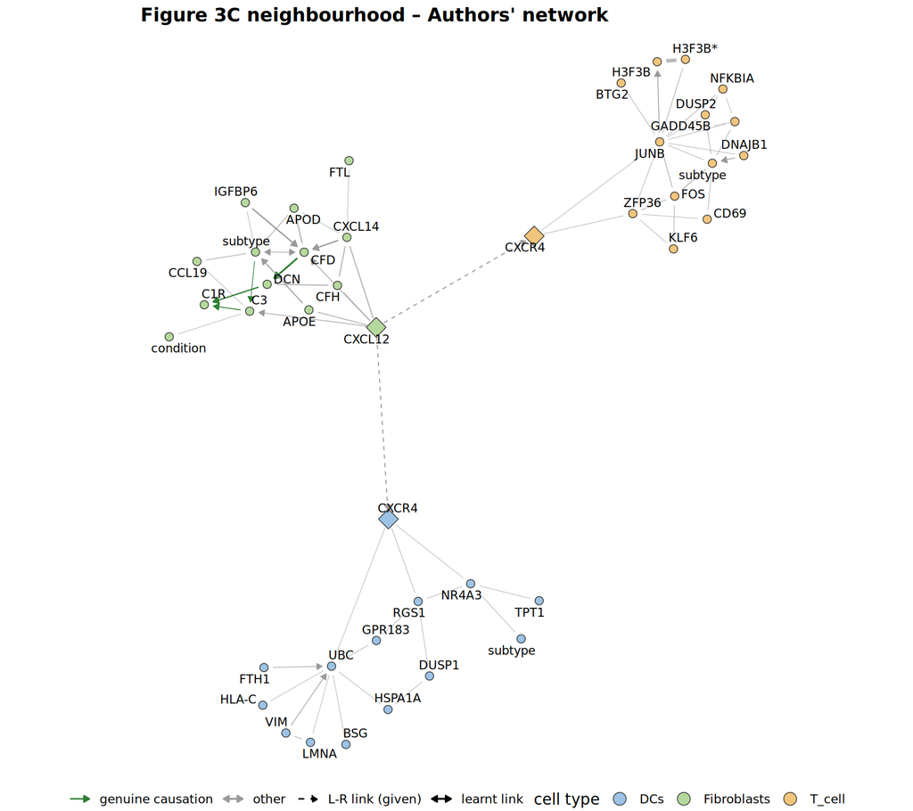

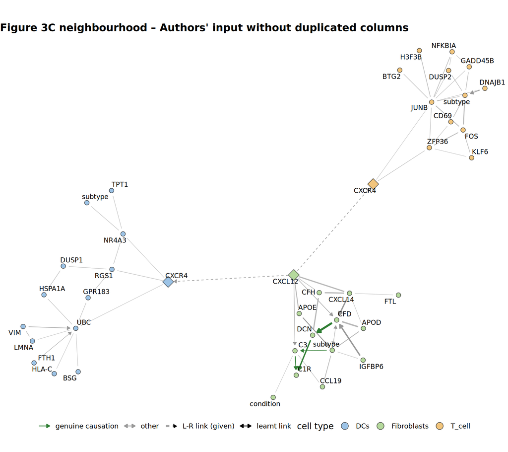

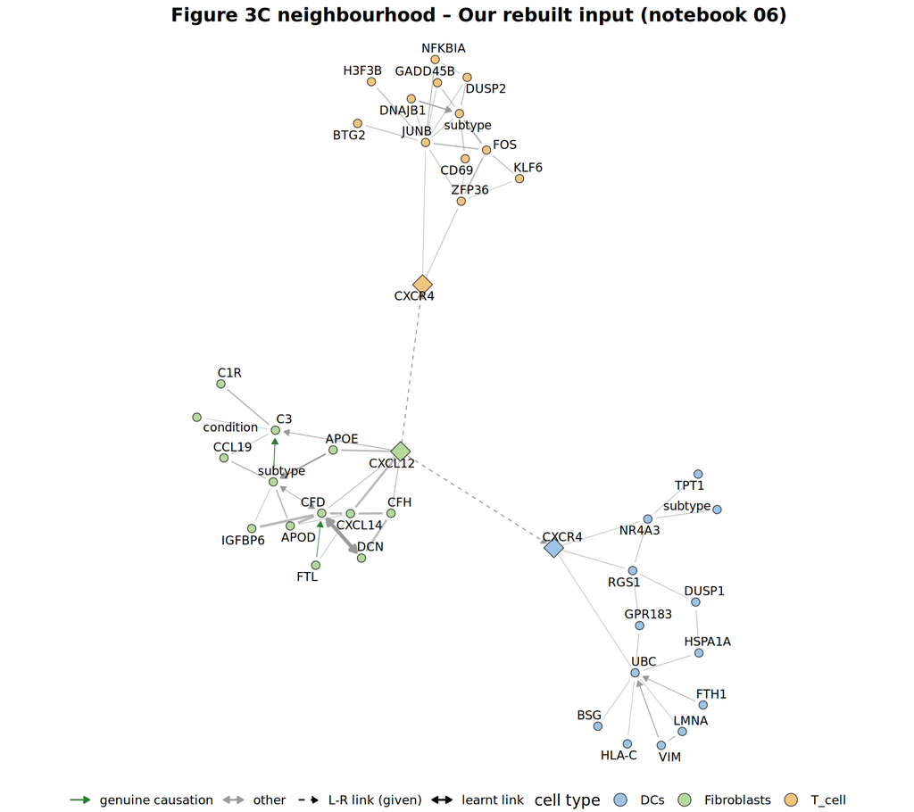

```r
figures_dir <- file.path(root, "results", "figures", "case2")
dir.create(figures_dir, recursive = TRUE, showWarnings = FALSE)

for (name in names(drawings)) {
  figure <- plot_network_static(drawings[[name]], title = paste("Figure 3C neighbourhood –", titles[[name]]))
  ggsave(file.path(figures_dir, paste0("fig3c_", name, ".png")), figure, width = 9, height = 8, dpi = 300)
  print(figure)
}
```

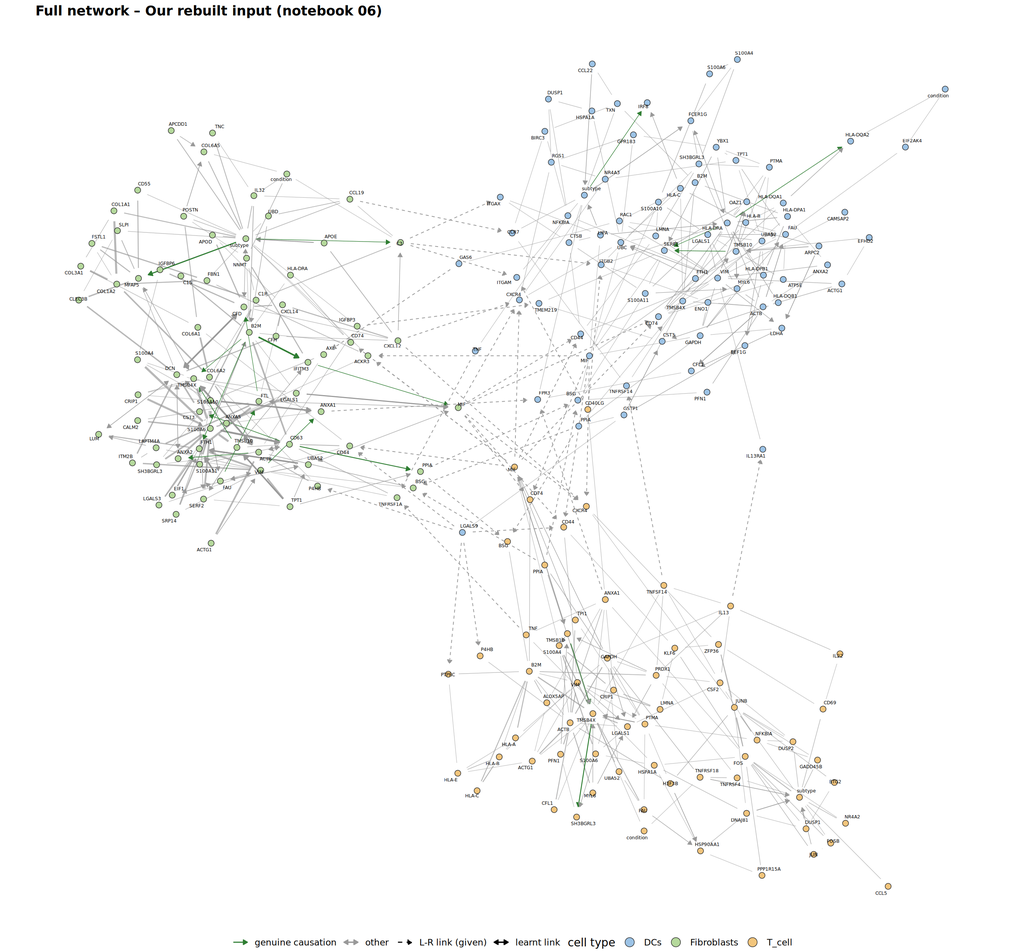

```r
full_networks <- list(
  authors = network_data(edges_authors, lr_links_authors, type_of_authors, \(v) gene_label(v, dropped)),
  authors_without_duplicates = network_data(edges_dedup, lr_links_authors, type_of_authors, gene_label),
  ours = network_data(edges_ours, lr_links_ours, type_of_ours, gene_label)
)

for (name in names(full_networks)) {
  figure <- plot_network_static(full_networks[[name]], title = paste("Full network –", titles[[name]]),
                                label_size = 1.6)
  ggsave(file.path(figures_dir, paste0("full_network_", name, ".png")), figure, width = 14, height = 13, dpi = 300)
}
print(figure)   # the last one (ours), as an example
```

```r
list.files(figures_dir)
```

```
[1] "fig3c_authors_without_duplicates.png"
[2] "fig3c_authors.png"
[3] "fig3c_ours.png"
[4] "full_network_authors_without_duplicates.png"
[5] "full_network_authors.png"
[6] "full_network_ours.png"
```

## What we learned

**Gene selection: the cause is found.** The code version is not the cause (the public code did not change), and neither is the gene order (MI values are exactly the same whatever the order). Since our counts are the authors’ counts, our MI values are the authors’ too, and the difference lies only in the selection settings. The authors’ selection is **reproduced exactly**, in all three cell types, by one wrapper run per sender → receiver direction with:

- **25 genes per run** instead of the default `max(15, min(4 × genes of interest, 100))`;
- **all** the ligands or receptors of the direction as features of interest, not only the first 8;
- the two metadata (`labels` and `condition`) as features of interest: `labels` alone on both sides leaves 4 genes missing, `condition` must be added on at least one side.

The last 5 missing dendritic cell genes were the clue: they are the top genes of TMEM219 and TNFRSF14, the two receptors removed by the cap of 8. These settings are not those of the published wrapper, and the paper does not mention them: the authors probably changed the wrapper or called the selection function themselves.

**Orientations: the duplicates make some of them contradictory.** On the authors’ input without its 14 duplicated columns, which is exactly the input the settings above produce:

- the **links are unchanged** (the same 525 gene–gene links, Jaccard index 1);
- the 414 links that do not involve a duplicated gene keep **exactly** the same orientation and the same 18 genuine causations;
- the 111 links of the duplicated genes appear once per copy in the authors’ network, and the two copies get **different orientations for 87 of them** (different causal status for 18). Without the duplicates each link has one orientation, always that of one of the two copies. Counting a link as a genuine causation when one of its copies is, the authors’ network has 41 genuine causations at the gene level (18 + 23), against 30 without the duplicates (18 + 12).

An earlier version of this notebook reported that “17 % of the orientations change”: this figure came from keeping one copy at random for the links of the duplicated genes (section 5).

Between the input without duplicates and our input of notebook 06 (default settings, about 7 % different genes), links differ more (Jaccard 0.82) and orientations agree on 94 % of the shared links. Figure 3 holds in the network without duplicates: the same distances for all the genes named in the paper, and CXCL12 → CFD is kept.

**Summary: what changes what.**

| Change made to the input | Effect on the links | Effect on the orientations |
| --- | --- | --- |
| Remove the 14 duplicated columns (same genes otherwise) | none (same 525 links, Jaccard 1) | none for the 414 links without a duplicated gene; the 111 links of the duplicated genes go from two (often contradictory) orientations to one |
| Default selection settings instead of the authors’ (about 7 % different genes) | links differ more (Jaccard 0.82) | 94 % of the shared links keep their orientation |

The duplicated columns therefore do not change the rest of the network: they give the links of the 14 duplicated genes two orientations instead of one. The gene selection acts mainly on the **links**.

**What this means.** Case study 2 can be rebuilt exactly from public data, provided the selection settings above are used. The duplicated columns are an artefact of the authors’ preparation: removing them changes no link and no orientation outside the links of the duplicated genes, but these 111 links have contradictory orientations in the published network. None of the genes named in Figure 3 is duplicated, so the paper’s claims are not affected.

**The opposite experiment (notebook 09).** We showed here what *removing* the duplicates does to the authors’ input. The direct test of the hypothesis is the opposite: *add* the 14 duplicated columns to the input rebuilt with the settings above and check that MIIC returns the authors’ network. We ran it in notebook 09: the rebuilt input has exactly the authors’ values in all 238 columns, and the resulting network is **identical** to the authors’ one (same links, orientations and genuine causations), although the column order is not the authors’ one. The only caveat is that the 14 genes to duplicate were taken from the authors’ table, because we cannot predict them (notebook 05).

**Questions for the authors.** How were the six wrapper runs pooled (origin of the duplicated columns)? Why 25 genes and no cap of 8, and are these the settings to use? Were the published L-R link strengths meant to come from a duplicated gene?